# Связь ориентации камбал с их размером в разных заливах Белого моря

В. Хайтов

09 03 2020

## Первичные данные

Для визуализации первичных данных можно рассмотреть частотные распределения значений длины.

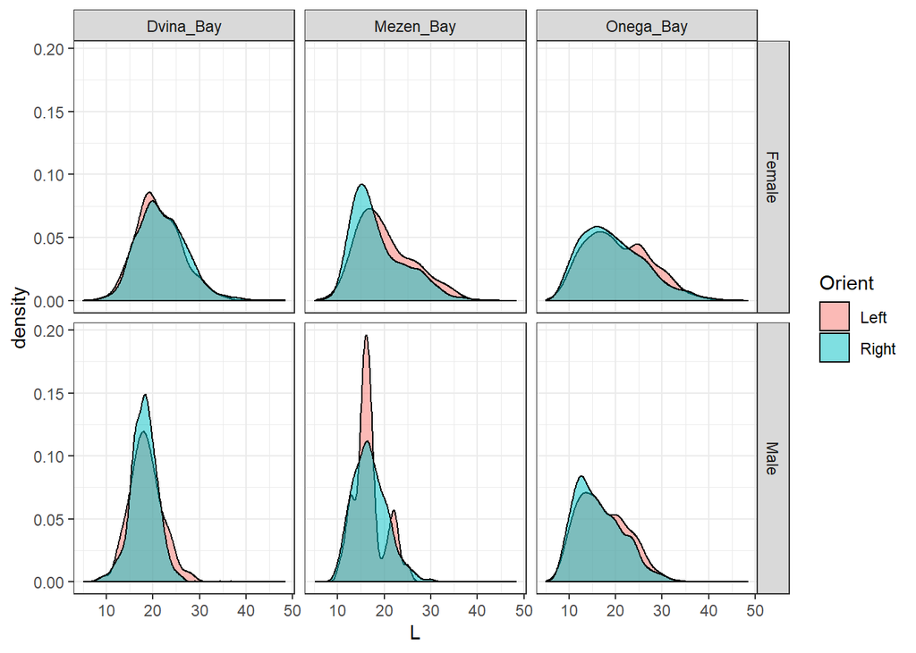

**Рисунок 1.** Частотное распределение размеров у рыб с разной ориентацией

Честно говоря, не очень говорящая картинка, разве что видно, что самцы чуть мельче самок. Прищурившись можно увидеть, что левосторонние слегка крупнее.

Вот другая визуализация.

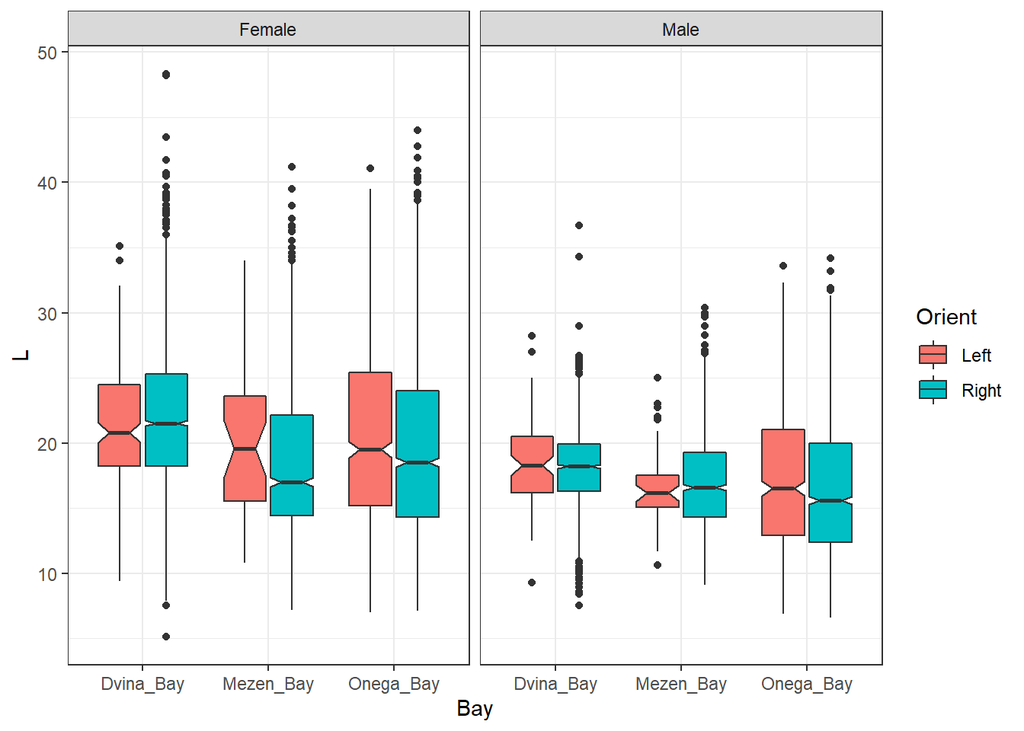

**Рисунок 2.** Размер рыб с разной ориентацией в разных заливах Белого моря.

Здесь становится видна некоторая тенденция к тому, что левосторонние камбалы слегка крупнее. По крайней мере, эта тенденция видна в Мезенском и Онежском заливах.

В целом, на глаз, в этом материале ничего не видно. Единственный вариант разобраться в этом - это построить регрессионную модель.

## Модель

Левосторонние камбалы рассматривались, как положительный исход (были кодированы, как “1”), правосторонние камбалы - как отрицательный исход (кодированы, как “0”).

Анализ данных будет строиться на построении регрессионной модели следующего вида

$$logit(P_{left}) = b_0 + b_1L + b_2I_{Male} + b_3I_{Onega} + b_4I_{Mesen} + Interactions$$

Вот результаты подбора модели.

**Таблица 1.** Параметры регрессионной модели

| term | estimate | std.error | statistic | p.value |
| --- | --- | --- | --- | --- |
| (Intercept) | -2.338 | 0.348 | -6.718 | 0.000 |
| L | -0.024 | 0.016 | -1.540 | 0.124 |
| SexMale | -1.368 | 0.789 | -1.733 | 0.083 |
| BayMezen_Bay | -1.902 | 0.663 | -2.870 | 0.004 |
| BayOnega_Bay | 0.854 | 0.374 | 2.286 | 0.022 |
| L:SexMale | 0.064 | 0.041 | 1.545 | 0.122 |
| L:BayMezen_Bay | 0.066 | 0.031 | 2.125 | 0.034 |
| L:BayOnega_Bay | 0.045 | 0.017 | 2.609 | 0.009 |
| SexMale:BayMezen_Bay | 2.605 | 1.236 | 2.108 | 0.035 |
| SexMale:BayOnega_Bay | 1.321 | 0.819 | 1.613 | 0.107 |
| L:SexMale:BayMezen_Bay | -0.123 | 0.066 | -1.845 | 0.065 |
| L:SexMale:BayOnega_Bay | -0.053 | 0.043 | -1.233 | 0.218 |

Анализ девиансы показал, что явных признаков взаимодействия предикторов нет.

**Таблица 2.** Результаты анализа девиансы для полученной модели

|  | LR Chisq | Df | Pr(>Chisq) |
| --- | --- | --- | --- |
| L | 15.324 | 1 | 0.000 |
| Sex | 2.464 | 1 | 0.116 |
| Bay | 1166.295 | 2 | 0.000 |
| L:Sex | 1.106 | 1 | 0.293 |
| L:Bay | 5.740 | 2 | 0.057 |
| Sex:Bay | 4.478 | 2 | 0.107 |
| L:Sex:Bay | 3.453 | 2 | 0.178 |

В связи с этим можно провести упрощение модели в соответствии с протоколом backward selection: пошаговое удаление членов модели, при контроле значений AIC (Информационный критерий Акаике). Финальной моделью считалась модель с минимальным AIC.

AIC для полной модели составил 8046.7, после удаления лишних предикторов AIC финальной модели составил 8045.3. Последняя величина меньше, чем начальная, что говорит о том, что отброс лишних элементов привел к улучшению модели.

Вот параметры финальной модели.

**Таблица 3.** Параметры финальной модели

| term | estimate | std.error | statistic | p.value |
| --- | --- | --- | --- | --- |
| (Intercept) | -3.347 | 0.128 | -26.216 | 0.000 |
| L | 0.019 | 0.005 | 3.968 | 0.000 |
| SexMale | 0.104 | 0.060 | 1.721 | 0.085 |
| BayMezen_Bay | -0.417 | 0.134 | -3.102 | 0.002 |
| BayOnega_Bay | 1.895 | 0.074 | 25.588 | 0.000 |

Вот ее анализ девиансы.

**Таблица 4.** Результаты анализа девиансы для финальной модели

|  | LR Chisq | Df | Pr(>Chisq) |
| --- | --- | --- | --- |
| L | 15.627 | 1 | 0.000 |
| Sex | 2.958 | 1 | 0.085 |
| Bay | 1165.278 | 2 | 0.000 |

Таким образом, частота встречи левосторонних камбал зависит от размера (L) и имеет разные значения в разных заливах Белого моря (Bay). Статистически значимой зависимости частоты встречи левосторонних камбал от пола (Sex) выявлено не было.

Для демонстрации полученных закономерностей визуализируем данную модель.

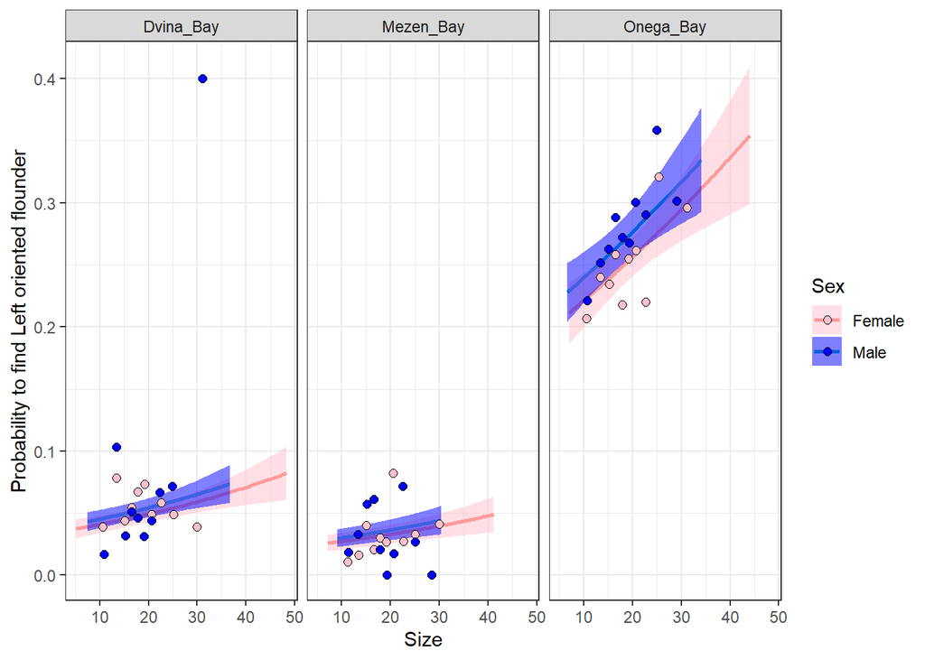

**Рисунок 3.** Зависимость вероятности встретить левостороннюю камбалу от размера у рыб в разных заливах Белого моря. Точками показаны частоты левосторонних особей в пределах раных размерных классов

Видны следующие закономерности.

1. Вероятность встретить левостороннюю камбалу значимо выше в материале, собранном в Онежском заливе. В Мезенском заливе вероятность встречи такой камбалы минимальна. Широтный градиент? Онежский заоив самый теплый, Двинский чуть севернее, Мезенский - самый северный. Было бы интересно засунуть сюда еще и данные по Кандалакшскому заливу. Если займет промежуточное положение, то, по-моему, это будет хорошим доказательством именно широтного градиента.
2. Чем больше размер рыбы, тем больше вероятность встретить левостороннюю особь. И эта закономерность прослеживается во всех заливах. Тут возможны две трактовки. Либо левосторонние растут быстрее, либо смертность у правосторонних выше и до большего размера доживает меньше особей.
3. Вероятность встретить левостороннюю особь, скорее всего, не связана с полом.